# INFO 201 Final Project: The effects of the fall of communism on the Olympic performance of Post-Soviet nations

Author

Rachel Chalissery, Nooria Hiyeri

Published

December 9, 2024

# Narrative

## Introduction

The dissolution of the Soviet Union in 1991 marked a seismic geopolitical shift, not only altering global political landscapes but also significantly impacting cultural and societal arenas, including sports. Among the many domains affected, the Olympic performance of former Soviet republics presents a unique lens to explore the interplay between economic development, political identity, and athletic prowess. This project investigates how the collapse of communism influenced Olympic success among post-Soviet nations, utilizing Olympic medal data and GDP statistics.

By examining medal counts and economic indicators from 1995, this analysis aims to uncover patterns in performance disparities between these newly independent nations and their Soviet predecessor. This study builds upon previous research on economic development’s influence on sports performance, such as studies by Bernard & Busse (2004) on GDP and Olympic success, and political identity’s role in national representation in sports, as highlighted by Bairner (2001).

## Description of the Data and Methodology

### Data Sources:

1. Olympic Medal Data: Sourced from an official Olympic dataset, this data contains information on medal counts, country codes, and event years. The dataset provides a historical snapshot of athletic performance by both the USSR and its successor states.
2. GDP Data: Derived from the United Nations Statistics Division, the GDP dataset includes economic performance metrics, specifically GDP in current prices (millions of US dollars) for Soviet successor states in 1995. GDP serves as a proxy for economic recovery post-USSR dissolution.

### Potential Technical and Ethical Limitations:

1. Data Completeness: Olympic medal data may not account for non-medal-winning participants, thus offering a limited view of overall athletic engagement.
2. Temporal Bias: GDP data from 1995 may not capture long-term economic recovery patterns affecting Olympic performance.
3. Ethical Considerations: While aggregate country-level data minimizes privacy concerns, ethical questions arise when interpreting the impact of economic hardship on individual athletes.

## Findings and Patterns

### Olympic Medal Trends:

The USSR consistently dominated the Olympics, leveraging centralized state support and a unified identity to achieve significant success. After 1991, post-Soviet nations, such as Russia, continued to excel, retaining their legacy. However, smaller nations, such as Moldova and Tajikistan, experienced reduced medal counts, highlighting disparities in resource allocation and institutional support.

### Economic Influence:

Analysis of 1995 GDP data revealed significant economic disparities among post-Soviet nations. Russia and Kazakhstan, with higher GDP levels, showed stronger Olympic performance, aligning with the hypothesis that economic stability supports sports development. Conversely, nations like Moldova, with lower GDP, faced challenges maintaining pre-1991 levels of international competitiveness.

### Visualization Highlights:

A line chart displays the USSR’s medal dominance over time before its dissolution in 1991, contrasted with a bar chart displaying the fragmented performance of successor states. A geographic heatmap visualization illustrated GDP distribution among post-Soviet nations, highlighting economic inequality’s correlation with medal distribution.

## Comparison to Existing Literature

The findings align with Bernard & Busse (2004), who concluded that GDP is a significant predictor of Olympic success. Wealthier nations can invest in training infrastructure and athlete development, providing a competitive edge. Additionally, Bairner (2001) discusses how national identity shapes international sports performance, a dynamic observed in the varied trajectories of post-Soviet countries. For example, Russia retained its strong identity and infrastructure, while smaller nations grappled with establishing themselves on the global stage.

## Conclusions

This analysis highlights the enduring legacy of the Soviet sports system while underscoring the challenges faced by smaller post-Soviet nations. The transition from a centralized model to independent states introduced disparities in resources, affecting their Olympic presence. Furthermore, economic recovery appears to be a key factor influencing athletic success, emphasizing the interconnectedness of national prosperity and sports performance.

## Future Work

To deepen this analysis, future research could:

1. Extend the timeframe to include GDP and Olympic data from 1991-2020 to capture long-term trends.
2. Investigate the role of international collaborations and foreign training programs in post-Soviet sports recovery.
3. Explore individual athletes’ narratives to better understand the human impact of political and economic transitions.

## References

1. Bernard, A. B., & Busse, M. R. (2004). “Who wins the Olympic Games: Economic resources and medal totals.” Review of Economics and Statistics.
2. Bairner, A. (2001). Sport, nationalism, and globalization: European and North American perspectives. SUNY Press.
3. United Nations Statistics Division. “GDP and GDP Per Capita Dataset.” UN Data.

## Load Libraries

```r
library(tidyverse)
```

## Load Data

```r
olympic_data <- read.csv("olympic_medals.csv")
olympic_data |> glimpse()
```

```
Rows: 21,697
Columns: 12
$ discipline_title      <chr> "Curling", "Curling", "Curling", "Curling", "Cur…
$ slug_game             <chr> "beijing-2022", "beijing-2022", "beijing-2022", …
$ event_title           <chr> "Mixed Doubles", "Mixed Doubles", "Mixed Doubles…
$ event_gender          <chr> "Mixed", "Mixed", "Mixed", "Mixed", "Mixed", "Mi…
$ medal_type            <chr> "GOLD", "GOLD", "SILVER", "SILVER", "BRONZE", "B…
$ participant_type      <chr> "GameTeam", "GameTeam", "GameTeam", "GameTeam", …
$ participant_title     <chr> "Italy", "Italy", "Norway", "Norway", "Sweden", …
$ athlete_url           <chr> "https://olympics.com/en/athletes/stefania-const…
$ athlete_full_name     <chr> "Stefania CONSTANTINI", "Amos MOSANER", "Kristin…
$ country_name          <chr> "Italy", "Italy", "Norway", "Norway", "Sweden", …
$ country_code          <chr> "IT", "IT", "NO", "NO", "SE", "SE", "GB", "JP", …
$ country_3_letter_code <chr> "ITA", "ITA", "NOR", "NOR", "SWE", "SWE", "GBR",…
```

### UN Dataset – Statistical Yearbook GDP:

As for this dataset, it gives detailed economic data regarding GDP and additionally GDP per capita for countries across the world. All in all, it supports the big picture analyses of economic trends and also several comparisons surrounding various regions and time periods too.

```r
gdp_data <- read.csv("SYB66_230_202310_GDP and GDP Per Capita.csv")
gdp_data |>
  glimpse()
```

```
Rows: 6,775
Columns: 7
$ Region.Country.Area <int> 1, 1, 1, 1, 1, 1, 1, 1, 1, 1, 1, 1, 1, 1, 1, 1, 1,…
$ Region              <chr> "Total, all countries or areas", "Total, all count…
$ Year                <int> 1995, 2005, 2010, 2015, 2019, 2020, 2021, 1995, 20…
$ Series              <chr> "GDP in current prices (millions of US dollars)", …
$ Value               <chr> "31,269,041", "47,775,404", "66,578,017", "75,283,…
$ Footnotes           <chr> "", "", "", "", "", "", "", "", "", "", "", "", ""…
$ Source              <chr> "United Nations Statistics Division, New York, Nat…
```

## USSR in the Olympics

### Filtering the Olympic Dataset

Tidying up and filtering the dataset so it shows how many medals the USSR won in the Olympics each year

```r
filtered_olympic_data <- olympic_data |>
  mutate(year = as.numeric(sub(".*-(\\d{4})", "\\1", slug_game))) |>
  arrange(year) |>
  filter(country_3_letter_code == "URS") |>
  group_by(slug_game, year) |>
  summarize(medal_count = n(), .groups = 'drop')
filtered_olympic_data |> sample_n(10)
```

```
# A tibble: 10 × 3
   slug_game               year medal_count
   <chr>                  <dbl>       <int>
 1 squaw-valley-1960       1960          21
 2 munich-1972             1972         105
 3 innsbruck-1976          1976          30
 4 helsinki-1952           1952          72
 5 grenoble-1968           1968          15
 6 lake-placid-1980        1980          26
 7 seoul-1988              1988         138
 8 moscow-1980             1980         202
 9 melbourne-1956          1956         103
10 cortina-d-ampezzo-1956  1956          16
```

### Visualizing the USSRs Olympic perfomance

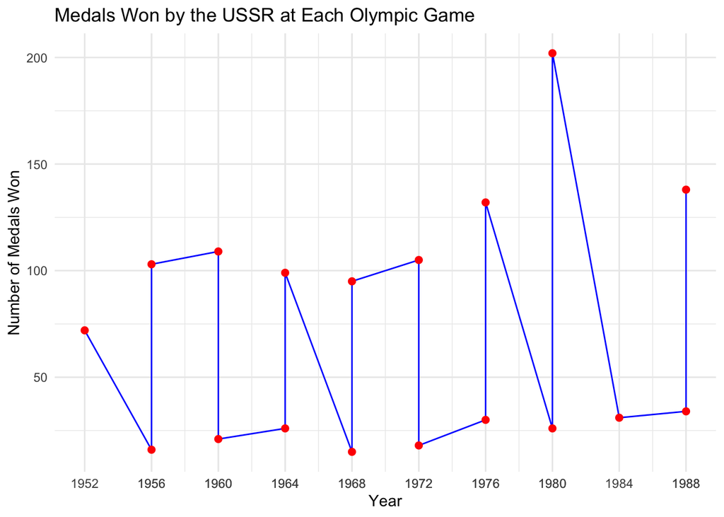

```r
ggplot(filtered_olympic_data, aes(x = year, y = medal_count)) +
  geom_line(color = "blue") +
  geom_point(color = "red", size = 2) +
  labs(title = "Medals Won by the USSR at Each Olympic Game",
       x = "Year",
       y = "Number of Medals Won") +
  theme_minimal() +
  scale_x_continuous(breaks = filtered_olympic_data$year)
```

## GDP of Post-Soviet Nations in 1995

### Tidying the GDP Dataset

Tidying and Filtering the GDP dataset to show the GDP of post-soviet countires in 1995 (around when the 1996 and 1998 Olympic games occured)

```r
soviet_union_countries <- c(
  "Armenia", "Azerbaijan", "Belarus", "Estonia", "Georgia",
  "Kazakhstan", "Kyrgyzstan", "Latvia", "Lithuania", "Moldova",
  "Russia", "Tajikistan", "Turkmenistan", "Ukraine", "Uzbekistan"
)
gdp_data$Value <- as.numeric(gsub(",", "", gdp_data$Value))

gdp_data$Region <- recode(gdp_data$Region,
                          "Russian Federation" = "Russia",
                          "Republic of Moldova" = "Moldova")
filtered_gdp <- gdp_data |>
  filter(Year == 1995) |>
  filter(Region %in% soviet_union_countries) |>
  filter(Series == "GDP in current prices (millions of US dollars)") |>
  rename(region = Region) |>
  mutate(Value = Value / 1000)

filtered_gdp |> sample_n(15)
```

```
   Region.Country.Area       region Year
1                  643       Russia 1995
2                  268      Georgia 1995
3                  498      Moldova 1995
4                  398   Kazakhstan 1995
5                  795 Turkmenistan 1995
6                  112      Belarus 1995
7                   51      Armenia 1995
8                  428       Latvia 1995
9                  762   Tajikistan 1995
10                 440    Lithuania 1995
11                  31   Azerbaijan 1995
12                 860   Uzbekistan 1995
13                 804      Ukraine 1995
14                 417   Kyrgyzstan 1995
```

[output cut: 33 more lines]

### Visualizing the Former Soviet Nations’ GDP in current prices

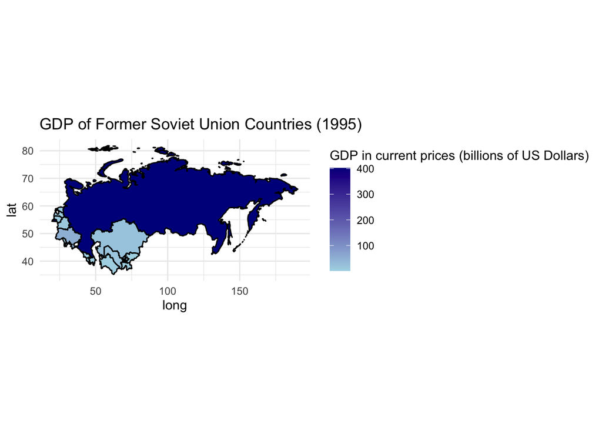

## Post-Soviet Nations performance in the 1996 and 1998 Olympics

### Tidying and Filtering the Olympic Dataset

Tidying and filtering the Olympic dataset to show the post-soviet nations’ performance in those 2 Olympic games

```r
post_soviet_name_list = c("Russian Federation", "Estonia", "Latvia", "Lithuania", "Republic of Moldova", "Belarus", "Armenia", "Georgia", "Kazakhstan", "Kyrgyzstan", "Ukraine", "Uzbekistan", "Azerbaijan", "Tajikistan", "Turkmenistan")
post_soviet_olympic_data <- olympic_data |>
  filter(country_name %in% post_soviet_name_list) |>
  filter(slug_game == "atlanta-1996" | slug_game == "nagano-1998") |>
  ungroup() |>
  group_by(country_name) |>
  summarize(medal_count = n()) |>
  complete(country_name = post_soviet_name_list, fill = list(medal_count = 0))
post_soviet_olympic_data |> sample_n(11)
```

```
# A tibble: 11 × 2
   country_name        medal_count
   <chr>                     <int>
 1 Tajikistan                    0
 2 Kyrgyzstan                    0
 3 Ukraine                      26
 4 Republic of Moldova           3
 5 Azerbaijan                    1
 6 Georgia                       2
 7 Lithuania                     1
 8 Estonia                       0
 9 Belarus                      17
10 Latvia                        1
11 Turkmenistan                  0
```

### Visualizing the Post-Soviet Nations’ Olympic Performance

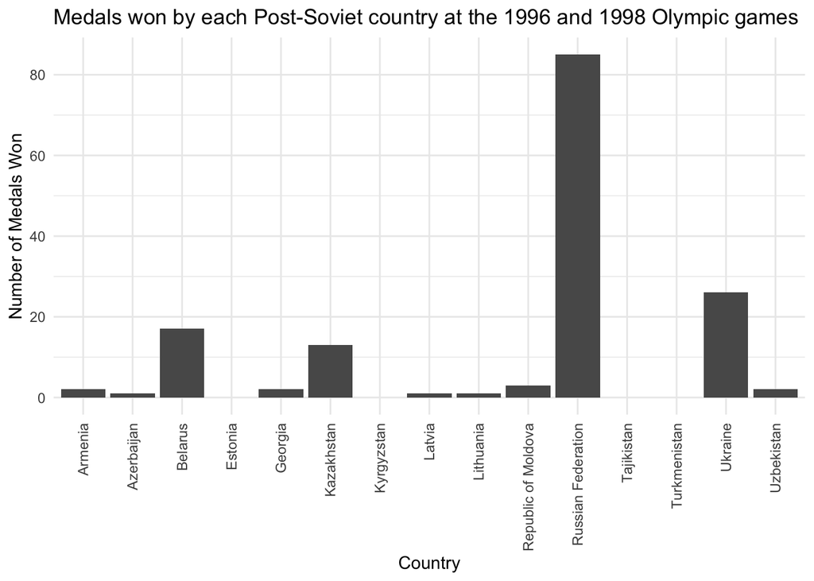

```r
ggplot(post_soviet_olympic_data, aes(x = country_name, y = medal_count)) +
  geom_bar(stat = "identity") +
  labs(title = "Medals won by each Post-Soviet country at the 1996 and 1998 Olympic games",
       x = "Country",
       y = "Number of Medals Won") +
  theme_minimal() +
  theme(axis.text.x = element_text(angle = 90, vjust = 0.5, hjust=1))
```